# Lab-5: Assignment

Author

Dheeraj Oruganty

## Problem 1:

$X \sim U(0,1)$ and $Y \sim U(0,1)$.

Plot the joint distribution of X & Y such that $X+Y < 1$

`Numerical Example`

$\left(X_1, X_2\right)$ with the range $\left\{\left(x_1, x_2\right) \mid x_1 \geq 0, x_2 \geq 0, x_1+x_2 \leq 1\right\}$ and the joint desity function $f\left(x_1, x_2\right)=2$ on this range.

1. First make a large number of samples from $X \sim U(0,1)$ and $Y \sim U(0,1)$ and plot X & Y and then plot the samples below the line $x+y = 1$ .

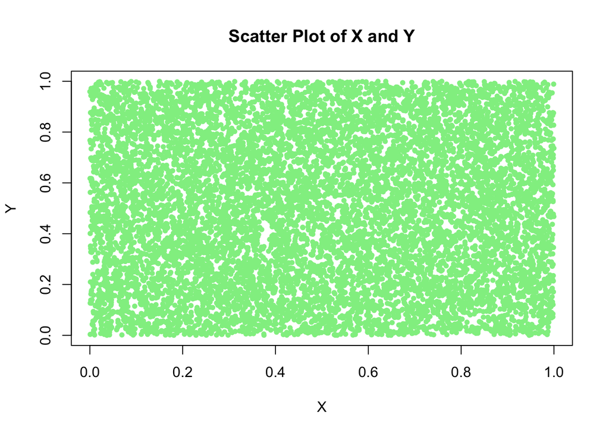

```r
set.seed(1000)
x <- replicate(10000, runif(1, min = 0, max = 1))

y <- replicate(10000, runif(1, min = 0, max = 1))

data <- data.frame(x, y)

plot(data$x, data$y, pch = 20, col = "lightgreen", xlab = "X", ylab = "Y", main = "Scatter Plot of X and Y")
```

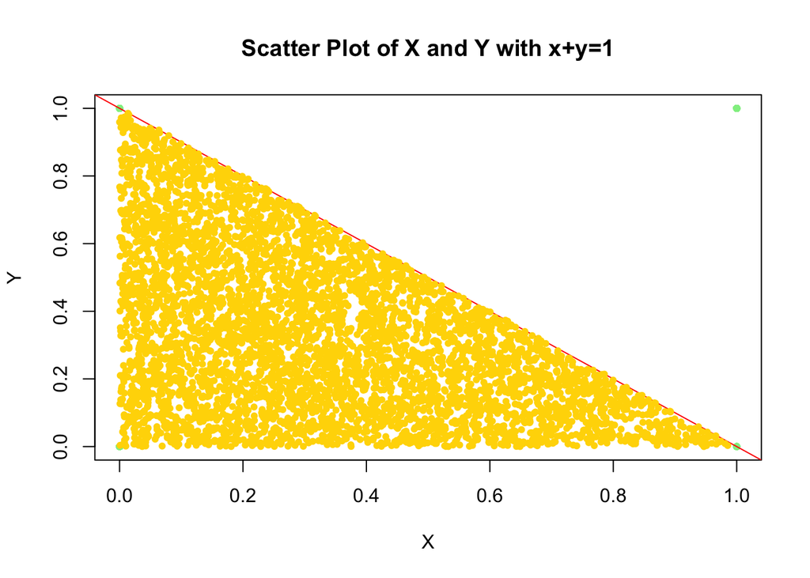

```r
plot(data$x < 0.5, data$y < 0.5 , pch = 20, col = "lightgreen", xlab = "X", ylab = "Y", main = "Scatter Plot of X and Y with x+y=1")

abline(1,-1 , col = "red")


points(data$x[data$x + data$y < 1], data$y[data$x + data$y < 1], pch = 20, col = "gold")
```

2. By looking at the plot, what is the joint p.d.f $f(X,Y)$?
- The region below the line $(x + y = 1)$ is a triangle with vertices at (0,0), (1,0), and (0,1). The area of this triangle is 0.5, as it is half of a unit square.

Since the joint probability density function (p.d.f.) integrates to 1 over the entire range, we can define the joint p.d.f. of X and Y as:

$$f(X, Y) = \begin{cases} 2 & \text{for } 0 \leq X \leq 1, 0 \leq Y \leq 1, \text{ and } X + Y \leq 1 \\0 & \text{otherwise}\end{cases}$$

3. Find the marginal distribution of X by hand and making a probability histogram. Compare whether these are the same. (Hint: think about the limits of X and Y according to $0<X+Y<1$)
- $$0 < X + Y < 1$$

  integrating $f(X, Y)$ with respect to Y:
  $$f_X(X) = \int_{{0}}^{{1-X}} 2 \, dy$$

  $$f_X(X) = 2\left[y\right]_{{0}}^{{1-X}} = 2(1-X)$$

  The marginal distribution of X is:

  $$f_X(X) = 2(1-X)$$

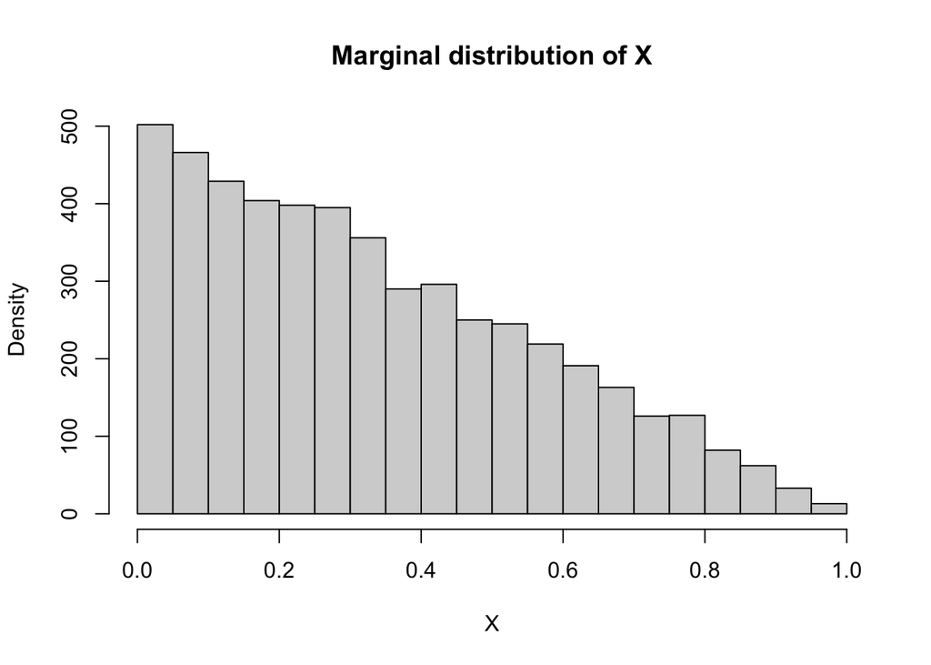

```r
fx <- 2 - 2*x

hist(x[x+y<1], breaks = 20, xlab = 'X', ylab = 'Density', main = 'Marginal distribution of X')
```

The Marginal Distribution of X by hand and the probability histogram display the same results.

4. Find the marginal distribution of Y by hand and making a probability histogram. Compare whether these are the same. (Hint: think about the limits of X and Y according to $0<X+Y<1$)
- $$0 < X + Y < 1$$

  integrating $f(X, Y)$ with respect to X:

  $$f_Y(Y) = \int_{{0}}^{{1-Y}} 2 \, dx$$

  $$f_Y(Y) = 2\left[x\right]_{{0}}^{{1-Y}} = 2(1-Y)$$

  So, the marginal distribution of Y is:

  $$f_Y(Y) = 2(1-Y)$$

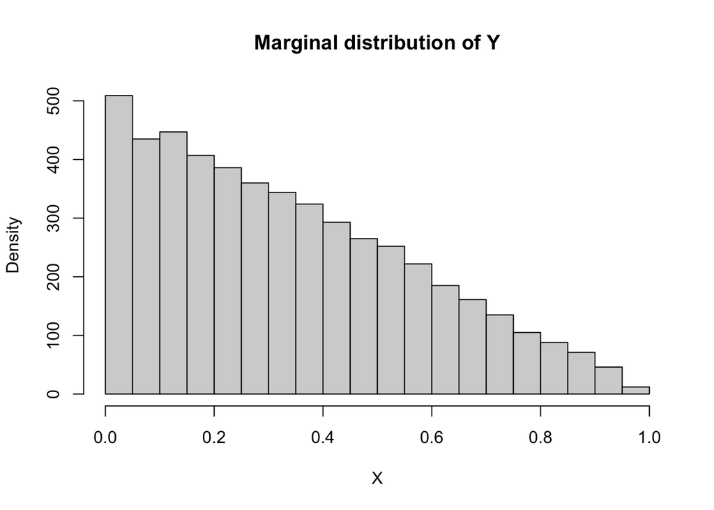

```r
hist(y[x+y<1], breaks = 20, xlab = 'X', ylab = 'Density', main = 'Marginal distribution of Y')
```

The Marginal Distribution of Y by hand and the probability histogram display the same results.

## Problem 2: Joint distributions and Conditional Expectations.

A CDF is defined by

$$\begin{aligned}
F(x,y) &= \begin{cases} Cx^2y(x+y^2) \quad (0 \leq y \leq 3, 0 \leq x \leq 2)\\
0 \quad (otherwise)
\end{cases}
\end{aligned}$$

1. Find the joint probability density function.

The Probability density function is defined as the derivative of the CDF function

$$\begin{aligned}
&\frac{\partial^2}{\partial x \partial y}\left(C x^2 y\left(x+y^2\right)\right)\\
&\begin{aligned}
& \frac{\partial}{\partial x}\left(C x^2 y\left(x+y^2\right)\right)=C y\left(3 x^2+2 x y^2\right) \\
& =\frac{\partial}{\partial \boldsymbol{y}}\left(C y\left(3 \boldsymbol{x}^2+2 x y^2\right)\right)
\end{aligned}\\
&\begin{aligned}
& \frac{\partial}{\partial y}\left(C y\left(3 x^2+2 x y^2\right)\right)=C\left(3 x^2+6 x y^2\right) \\
& =C\left(3 \boldsymbol{x}^2+\mathbf{6 x y}^2\right)
\end{aligned}
\end{aligned}$$

2. Find the value of $C$.

$$\begin{aligned}
&\int_0^3 \int_0^2 C\left(3 x^2+6 x y^2\right) d x d y\\
&\begin{aligned}
& \int_0^2 C\left(3 x^2+6 x y^2\right) d x=C\left(8+12 y^2\right) \\
& =\int_{\mathbf{0}}^{\mathbf{3}} \boldsymbol{C}\left(\mathbf{8}+\mathbf{1 2} \boldsymbol{y}^{\mathbf{2}}\right) \boldsymbol{d y}
\end{aligned}\\
&\begin{aligned}
& \int_0^3 C\left(8+12 y^2\right) d y=132 C \\
& \mathbf{1 3 2 C} = 1
\end{aligned}
\end{aligned}$$

$$C = 1/132$$

3. Find the Marginal density of $X$

$$\int_0^3 C\left(3 x^2+6 x y^2\right) d y$$
$$Take the constant out: $\int a \cdot f(x) d x=a \cdot \int f(x) d x$$
$$=C \cdot \int_0^3 3 x^2+6 x y^2 d y$$
Apply the Sum Rule: $\int f(x) \pm g(x) d x=\int f(x) d x \pm \int g(x) d x$
$$\left.=C_( \int_0^3 3 x^2 d y+\int_0^3 6 x y^2 d y\right)$$
$$\int_0^3 3 x^2 d y=9 x^2$$
$$\int_0^3 6 x y^2 d y=54 x$$
$$=C\left(9 x^2+54 x\right)$$

4. Find the Conditional expectation $E(Y|X)$

$$\int_0^3 y \frac{3 C x^2+6 C x y^2}{9 C x^2+54 C x} d y$$
Take the constant out: $\int a \cdot f(x) d x=a \cdot \int f(x) d x$
$$=\frac{1}{54 C x+9 C x^2} \cdot \int_0^3\left(3 C x^2+6 C x y^2\right) y d y$$
Expand $\left(3 C x^2+6 C x y^2\right) y: \quad 3 C x^2 y+6 C x y^3$
$$=\frac{1}{54 C x+9 C x^2} \cdot \int_0^3 3 C x^2 y+6 C x y^3 d y$$
Apply the Sum Rule: $\int f(x) \pm g(x) d x=\int f(x) d x \pm \int g(x) d x$
$$=\frac{1}{54 C x+9 C x^2}\left(\int_0^3 3 C x^2 y d y+\int_0^3 6 C x y^3 d y\right)$$
$$\int_0^3 3 C x^2 y d y=\frac{27 C x^2}{2}$$
$$\int_0^3 6 C x y^3 d y=\frac{243 C x}{2}$$
$$=\frac{1}{54 C x+9 C x^2}\left(\frac{27 C x^2}{2}+\frac{243 C x}{2}\right)$$
Simplify $\frac{1}{54 C x+9 C x^2}\left(\frac{27 C x^2}{2}+\frac{243 C x}{2}\right): \quad \frac{3(x+9)}{2(x+6)}$
$$=\frac{3(x+9)}{2(x+6)}$$

## Problem 3: Optional (don’t need to submit)

Let $Y \sim N(0,1)$ have a standard normal distribution. Set $X=\lfloor Y\rfloor$ (floor function).

- Find median $(Y \mid X=x)$ from simulations and plot it as a function of $x$.
- Find $s d(Y \mid X=x)$ from simulations and plot it as a function of $x$.
1. Do this with a data frame. Two columns, one for X and one for Y. use *floor()* function.

   *floor function:* https://en.wikipedia.org/wiki/Floor_and_ceiling_functions
2. Find the median $Y|X$ and plot. (You can use the *aggregate()* function.). Comment.
3. Find the standard deviation of $Y|X$ and plot. (You can use the *aggregate()* function.). Comment.